# Psych251.final.report-Reproducibility Report for Individual Differences in the Association Between Subjective Stress and Heart Rate Are Related to Psychological and Physical Well-Being by Sommerfeldt et al., (2019, Psychological Science)

Kris Evans

11/20/2020

```r
### Data Preparation included cleaning, and transformations, see cleaning .rmd for details
#### Load Relevant Libraries and Functions
#### Import data
#### Data exclusion / filtering - all participants who did did nothave five measures of stress and hr are in this data - kept those who only had stroop/math as their tp1 and 2 tasks dropped others, droppped NAs at hradn stress data aswellneeded all 5
#### Prepare data for analysis - create columns etc.

library(tidyverse)
```

```r
library(knitr)
library(sjPlot)
library(lmerTest)
library(psych)
library(readr)
library(gtsummary)
library(png)
#load wide and long data sets

psych_251_report_cleaned_wide <- read_csv("/Users/krise/R Mac working folder/sommerfeldt2019/psych.251.report.cleaned.wide.csv")
psych_251_report_cleaned_long <- read_csv("/Users/krise/R Mac working folder/sommerfeldt2019/psych.251.report.cleaned.long.csv")
wDF <- psych_251_report_cleaned_wide
f.Ldf <- psych_251_report_cleaned_long
```

## Introduction

This study aimed to establish and validate the value of a particular construct described as coherence. Coherence is a measure of accordance between self-reported stress and heart rate. Evidence suggests coherence is associated with healthy mind-body functioning and adaptivity. The authors hypothesize that the within-participants association between self-reported stress and heart rate is positively related to psychological and physical well-being and negatively related to denial coping.

I chose to reproduce the analyses for this study due to the rich, multi-modal, and dimensional data available and my interest in adding the methods to my toolkit. I’m particularly interested in interventions that use this measure as a means of enhancement of meta-awareness, health, and well-being.

**Key analysis**

Using linear mixed-effects models, I will use the coherence model below to investigate the relationship of coherence with measures of health and well-being. Fundamental analyses include replicating the stress-heart rate model to predict well-being across various measures (psychological well-being, depression, anxiety, interleukin-6, and denial coping).

I will focus on the interaction effect in this model, representing the degree to which within-participants associations between self-reported stress and heart rate are related to the well-being indicator (PWB, depression, anxiety, IL-6, and CRP) or denial coping.

### Justification for choice of study

I chose to reproduce this study for three main reasons. One is because I get to use a rich and robust data set that would be impossible to replicate due to the expansive and longitudinal nature. Additionally, this data set’s multi-modal nature may stimulate future inquiry and publication that spans across domains. The second and third reason is my interest in gaining a better grasp and practice using the statistical and operational methods in this study for possible future use or exploratory analyses.

### Anticipated challenges

I foresee some challenges related to data analysis and interpretation based on adequate cleaning and wrangling. I do have access to the raw and processed data, which should reduce that challenge, but because this requires cleaning, tidying, and transforming many different variables, it introduces chances of error. It may be challenging to understand and justify the methods of the models fully.

### Links

*Project repository* (https://github.com/cardinal24/writeup.git):

*Original paper PDF and working files* (https://github.com/cardinal24/sommerfeldt2019.git):

## Methods

"Participants completed a standardized laboratory-based experimental stress-induction paradigm designed to measure cardiovascular reactivity and recovery from stress (Crowley et al., 2011) detailed documentation of the study protocol is publicly available at http://www.midus.wisc.edu/midus2/project4/). The data were collected at the University of California, Los Angeles; Georgetown University; and the University of Wisconsin and processed at the Columbia University Medical Center in the laboratory of Richard Sloan.

The stress-induction paradigm involved a resting baseline (11 min); two cognitive-psychological stressor tasks (6 min each; counterbalanced across participants); a seated, resting period after each task (recovery period; 6 min each); and an orthostatic challenge, which involved moving from a seated to a standing position and remaining standing (6 min). The orthostatic phase of the task was not included in the analyses because changes in heart rate during this phase are confounded with physical movement. Thus, we examined five phases of interest: baseline, first stressor task, first recovery, second stressor task, and second recovery.

Participants’ heart rate was measured using electrocardiograph electrodes placed on the left and right shoulders and in the left lower quadrant. Heart rate was measured continuously over every phase of the task. Heart rate was calculated as an average of all valid interbeat intervals and converted from interbeat-interval units (milliseconds) to beats-per-minute units. The average of a 5-min epoch was analyzed for each of the five phases of the task. Each epoch was scored for quality, and only epochs containing a full 5 min of good signal quality, without any designated invalid intervals of data that had to be omitted, were included in the analysis. We chose to examine the average heart rate for each phase of the task because the precise timing of each subjective report was not recorded on the physiological time series, and subjective reports did not necessarily occur during the peak physiological response.

Participants were informed at the beginning of the session that, periodically, they would be asked for a verbal stress rating on a scale from 1 (not stressed at all) to 10 (extremely stressed). The experimenter prompted each participant to verbally report his or her level of stress approximately 20 to 30 s before the end of each phase of the task. Thus, a total of six self-reports of stress were collected during the session, near the end of each phase: baseline, during each stressor task, during the recovery period following each stressor task, and after the orthostatic challenge. The first five self-reports of stress were used, excluding the ortho-static time point.".

For the LMEM approach, I will regress heart rate on self-reported stress (centered around each participant’s own mean), the well-being indicator under consideration (mean centered; e.g., PWB), and their interaction, adjusting for age, the interaction between self-reported stress and age, and nonindependence due to participants and families (Brauer & Curtin, 2018). Our model thus includes six fixed effects: self-reported stress (Level 1), the well-being indicator of interest (Level 2), their interaction, age (Level 2), the interaction of self- reported stress and age, and the intercept. The model includes a by-participant random intercept, a by-participant random slope for stress, and a by-family random intercept. The two by-participant random effects were allowed to correlate.

### Description of the steps required to reproduce the results

Retrieve, clean, analyze, interpret, and visualize key data, models and tables.

### Differences from original study

For this reproduction, the final N for analyses was 967. This population count is lower than the original paper (n=1065) reported and is likely due to different exclusion parameters resulting in a difference of 98 participants. Unlike the authors, I removed participants who did not have five self-reported stress and heart rate measures, as opposed to just stress. Additionally, I did not change scores on the PWB measure to NA if they equaled 98, which was not reported in the paper but shown in the authors’ coding script. I likely eliminated more participants in cleaning and transformations, which may have impacted variables differently.

## Results

```r
#basic summary stats of data
f.Ldf %>% tbl_summary(statistic = list(all_continuous() ~ "{mean} ({sd})")) #Mean and SDs fo all variables, those that were clustered, mean centered, and log transformed for analyses
```

| **Characteristic** | **N = 4,835**<sup>1</sup> |
| --- | --- |
| X1 | 2,418 (1,396) |
| M2ID | 14,766 (2,658) |
| timepoint |  |
| 1 | 967 (20%) |
| 2 | 967 (20%) |
| 3 | 967 (20%) |
| 4 | 967 (20%) |
| 5 | 967 (20%) |
| stress_value | 3.11 (2.12) |
| hr_value | 75 (11) |
| pwb2.x | 233 (35) |
| Unknown | 100 |
| COPE_denial.x | 6.09 (2.22) |
| Unknown | 95 |
| IL6.x | 2.99 (2.87) |
| Unknown | 25 |
| CRP.x | 2.88 (4.21) |
| Unknown | 55 |
| P4_CESD.x | 9 (8) |
| Unknown | 35 |
| P4_STAItrait.x | 34 (9) |
| Unknown | 40 |
| M2FAMNUM.x | 110,503 (8,314) |
| Unknown | 895 |
| P4_age.x | 56 (11) |
| stress_CMC | 0.00 (1.63) |
| hr_CMC | 0.00 (2.69) |
| pwb2_CMC | 0 (0%) |
| Unknown | 100 |
| P4_CESD_CMC | 0 (0%) |
| Unknown | 35 |
| COPE_d_CMC | 0 (0%) |
| Unknown | 95 |
| IL6_CMC | 0 (0%) |
| Unknown | 25 |
| CRP_CMC | 0 (0%) |
| Unknown | 55 |
| STAI_CMC | 0 (0%) |
| Unknown | 40 |
| P4_age_MC | 0 (11) |
| pwb2_MC | 0 (35) |
| Unknown | 100 |
| P4_CESD_MC | 0 (8) |
| Unknown | 35 |
| P4_STAItrait_MC | 0 (9) |
| Unknown | 40 |
| COPE_denial_MC | 0.00 (2.22) |
| Unknown | 95 |
| pwb2_MC_d10 | 0.0 (3.5) |
| Unknown | 100 |
| P4_CESD_MC_d10 | 0.00 (0.82) |
| Unknown | 35 |
| P4_STAItrait_MC_d10 | 0.00 (0.90) |
| Unknown | 40 |
| IL6_MC | 0.00 (2.87) |
| Unknown | 25 |
| CRP_MC | 0.00 (4.21) |
| Unknown | 55 |
| IL6_T | 1.16 (1.05) |
| Unknown | 25 |
| CRP_T | 0.17 (0.51) |
| Unknown | 55 |
| IL6_T_MC | 0.00 (1.05) |
| Unknown | 25 |
| CRP_T_MC | 0.00 (0.51) |
| Unknown | 55 |

<sup>*1*</sup> Statistics presented: Mean (SD); n (%)

### Data preparation

Data preparation included a thorough investigation of coding books, variables, cleaning, wrangling, and transforming (see cleaning .rmd for details). The variables in this data set are only related to key variables. Participants were excluded if they did not complete Stroop or MATH task for stress tasks or did not have five heart rates and self-reported stress measurements.

### Key analysis - Origiinal test and results

The statistical effect of stress on heart rate was found to be moderated by PWB, b = 0.050, F(1, 822.8) = 26.70, p < .0001; participants with higher stress–heart rate coherence also reported higher psychological well- being. The opposite was true for depressive symptoms, b = −0.249, F(1, 783.7) = 36.77, p < .0001, and trait anxiety, b = −0.211, F(1, 769.4) = 32.49, p < .0001; individuals with higher stress–heart rate coherence reported fewer depressive symptoms and had lower trait anxiety.

For physical well- being, the statistical effect of stress on heart rate was found to be significantly moderated by IL-6 and CRP; participants with higher stress–heart rate coherence also had lower IL-6, b = −0.145, F(1, 762.3) = 22.20, p < .0001, and lower CRP, b = −0.175, F(1, 827.2) = 7.16, p = .008.

I also investigated whether stress–heart rate coherence was associated with use of denial as a coping strategy.The statistical effect of stress on heart rate was found to be moderated by denial; higher stress–heart rate coherence was associated with less tendency toward the use of denial as a coping strategy, b = −0.069, F(1, 853.3) = 20.69, p < .0001

*Side-by-side graph with original graph is ideal here* Original author did not graph but listed the above numbers in a table. See below for tables and original or put table here.

### Exploratory analyses

None to report.

## Discussion

Primarily, the results indicate a significant relationship between heart rate and the interaction of stress and measures of health and well being. Specifically, individuals with higher stress-heart rate coherence also report higher psychological well-being, fewer depressive symptoms, lower trait anxiety, IL-6, CRP and are less likely to use denial as a coping strategy. I had similar results as the original authors for all the variables except CRP. Participants with higher stress-heart-rate coherence had lower CRP than those with lower stress-heart rate coherence, but this was non-significant but trending in the same direction as the original paper.

### Commentary

Overall, the original authors did an excellent job providing insight into their methods and approach and made this mostly available in an online repository. Access to materials and methods much supported this reproductive endeavor and is a critical part of open science. I only had one objection to a scoring method with the psychological well-being variable that I am not sure I understood, but this did not result in meaningful differences in the model results.

While the authors provided their code, there were no data to work from, so I had the opportunity to practice retrieving and digging through a massive data set with 10k+ observers and variables. This process helped me learn much more about the study and appreciate providing clean data sets when choosing open science methods. It also highlighted the original scientists’ incredible efforts and rigor that created and shared the original data because they had to anonymize track code and share these data sets. Their efforts have catalyzed hundreds of papers and highlights how open science can create new knowledge.

This reproduction taught me the value of using code, names, comments, and packages together optimally. This integrative consideration makes it easy to understand thinking processes and reproduce work from others and me! I learned that I need more practice wrangling data. I need to practice understanding why you want data to look a certain way and how to make it look that way for proper or most effective analyses. I now have some workflows, processes, and packages that will support the scientific journey.

# TESTS

## Stress-heart rate coherence association models

### Psychological Well-being

```r
# Run the Lmer tests
lmerM.pwb <- lmerTest::lmer(hr_value ~ stress_CMC * pwb2_MC_d10 + P4_age_MC*stress_CMC + (1 + stress_CMC|M2ID) + (1|M2FAMNUM.x), data = f.Ldf)
a.pwb <- anova(lmerM.pwb, type=3, test="F")
a.pwb
```

```
## Type III Analysis of Variance Table with Satterthwaite's method
##                        Sum Sq Mean Sq NumDF  DenDF  F value    Pr(>F)
## stress_CMC             3347.5  3347.5     1 534.69 594.8275 < 2.2e-16 ***
## pwb2_MC_d10               0.7     0.7     1 784.39   0.1193 0.7298802
## P4_age_MC               100.1   100.1     1 687.25  17.7861 2.803e-05 ***
## stress_CMC:pwb2_MC_d10   75.9    75.9     1 532.16  13.4785 0.0002657 ***
## stress_CMC:P4_age_MC     76.0    76.0     1 534.19  13.4961 0.0002631 ***
## ---
## Signif. codes:  0 '***' 0.001 '**' 0.01 '*' 0.05 '.' 0.1 ' ' 1
```

```r
#pwb.sum <- summary(lmerM.pwb)


tab_model(lmerM.pwb)
```

|  | hr_value |  |  |
| --- | --- | --- | --- |
| Predictors | Estimates | CI | p |
| (Intercept) | 74.74 | 73.97 – 75.51 | **<0.001** |
| stress_CMC | 0.94 | 0.87 – 1.02 | **<0.001** |
| pwb2_MC_d10 | 0.04 | -0.19 – 0.27 | 0.730 |
| P4_age_MC | -0.15 | -0.22 – -0.08 | **<0.001** |
| stress_CMC * pwb2_MC_d10 | 0.04 | 0.02 – 0.06 | **<0.001** |
| stress_CMC * P4_age_MC | -0.01 | -0.02 – -0.01 | **<0.001** |
| Random Effects |  |  |  |
| σ<sup>2</sup> | 5.63 |  |  |
| τ<sub>00</sub> <sub>M2ID</sub> | 92.34 |  |  |
| τ<sub>00</sub> <sub>M2FAMNUM.x</sub> | 22.97 |  |  |
| τ<sub>11</sub> <sub>M2ID.stress_CMC</sub> | 0.56 |  |  |
| ρ<sub>01</sub> <sub>M2ID</sub> | 0.18 |  |  |
| ICC | 0.95 |  |  |
| N <sub>M2ID</sub> | 788 |  |  |
| N <sub>M2FAMNUM.x</sub> | 686 |  |  |
| Observations | 3940 |  |  |
| Marginal R<sup>2</sup> / Conditional R<sup>2</sup> | 0.041 / 0.956 |  |  |

### Depression

```r
#run the tests
lmerM.dep <- lmerTest::lmer(hr_value ~ stress_CMC *P4_CESD_MC_d10 + P4_age_MC*stress_CMC + (1 + stress_CMC|M2ID) + (1|M2FAMNUM.x), data = f.Ldf)
a.dep<- anova(lmerM.dep, type=3, test="F")
a.dep
```

```
## Type III Analysis of Variance Table with Satterthwaite's method
##                           Sum Sq Mean Sq NumDF  DenDF  F value    Pr(>F)
## stress_CMC                3333.2  3333.2     1 524.06 589.9670 < 2.2e-16 ***
## P4_CESD_MC_d10               3.0     3.0     1 778.93   0.5386 0.4632335
## P4_age_MC                   95.4    95.4     1 671.52  16.8817  4.47e-05 ***
## stress_CMC:P4_CESD_MC_d10  116.5   116.5     1 500.89  20.6267  7.00e-06 ***
## stress_CMC:P4_age_MC        77.6    77.6     1 519.08  13.7335 0.0002333 ***
## ---
## Signif. codes:  0 '***' 0.001 '**' 0.01 '*' 0.05 '.' 0.1 ' ' 1
```

```r
#summary(lmerM.dep)

tab_model(lmerM.dep)
```

|  | hr_value |  |  |
| --- | --- | --- | --- |
| Predictors | Estimates | CI | p |
| (Intercept) | 74.75 | 73.97 – 75.52 | **<0.001** |
| stress_CMC | 0.94 | 0.86 – 1.01 | **<0.001** |
| P4_CESD_MC_d10 | 0.38 | -0.63 – 1.38 | 0.463 |
| P4_age_MC | -0.15 | -0.22 – -0.08 | **<0.001** |
| stress_CMC * P4_CESD_MC_d10 | -0.23 | -0.33 – -0.13 | **<0.001** |
| stress_CMC * P4_age_MC | -0.01 | -0.02 – -0.01 | **<0.001** |
| Random Effects |  |  |  |
| σ<sup>2</sup> | 5.65 |  |  |
| τ<sub>00</sub> <sub>M2ID</sub> | 91.23 |  |  |
| τ<sub>00</sub> <sub>M2FAMNUM.x</sub> | 23.75 |  |  |
| τ<sub>11</sub> <sub>M2ID.stress_CMC</sub> | 0.54 |  |  |
| ρ<sub>01</sub> <sub>M2ID</sub> | 0.20 |  |  |
| ICC | 0.95 |  |  |
| N <sub>M2ID</sub> | 785 |  |  |
| N <sub>M2FAMNUM.x</sub> | 684 |  |  |
| Observations | 3925 |  |  |
| Marginal R<sup>2</sup> / Conditional R<sup>2</sup> | 0.042 / 0.956 |  |  |

### Anxiety

```r
# Run the tests

lmerM.anx <- lmerTest::lmer(hr_value ~ stress_CMC *P4_STAItrait_MC_d10 + P4_age_MC*stress_CMC + (1 + stress_CMC|M2ID) + (1|M2FAMNUM.x), data = f.Ldf)
a.anx<- anova(lmerM.anx, type=3, test="F")
a.anx
```

```
## Type III Analysis of Variance Table with Satterthwaite's method
##                                Sum Sq Mean Sq NumDF  DenDF  F value    Pr(>F)
## stress_CMC                     3341.2  3341.2     1 527.46 592.5379 < 2.2e-16
## P4_STAItrait_MC_d10               0.2     0.2     1 771.68   0.0437 0.8344189
## P4_age_MC                       105.2   105.2     1 681.00  18.6648 1.791e-05
## stress_CMC:P4_STAItrait_MC_d10  104.1   104.1     1 488.85  18.4588 2.096e-05
## stress_CMC:P4_age_MC             72.9    72.9     1 523.17  12.9324 0.0003535
##
## stress_CMC                     ***
## P4_STAItrait_MC_d10
## P4_age_MC                      ***
## stress_CMC:P4_STAItrait_MC_d10 ***
## stress_CMC:P4_age_MC           ***
## ---
## Signif. codes:  0 '***' 0.001 '**' 0.01 '*' 0.05 '.' 0.1 ' ' 1
```

```r
#summary(lmerM.anx)

tab_model(lmerM.anx)
```

|  | hr_value |  |  |
| --- | --- | --- | --- |
| Predictors | Estimates | CI | p |
| (Intercept) | 74.71 | 73.94 – 75.49 | **<0.001** |
| stress_CMC | 0.94 | 0.86 – 1.02 | **<0.001** |
| P4_STAItrait_MC_d10 | 0.09 | -0.78 – 0.97 | 0.834 |
| P4_age_MC | -0.16 | -0.23 – -0.09 | **<0.001** |
| stress_CMC * P4_STAItrait_MC_d10 | -0.19 | -0.27 – -0.10 | **<0.001** |
| stress_CMC * P4_age_MC | -0.01 | -0.02 – -0.01 | **<0.001** |
| Random Effects |  |  |  |
| σ<sup>2</sup> | 5.64 |  |  |
| τ<sub>00</sub> <sub>M2ID</sub> | 92.29 |  |  |
| τ<sub>00</sub> <sub>M2FAMNUM.x</sub> | 22.48 |  |  |
| τ<sub>11</sub> <sub>M2ID.stress_CMC</sub> | 0.55 |  |  |
| ρ<sub>01</sub> <sub>M2ID</sub> | 0.19 |  |  |
| ICC | 0.95 |  |  |
| N <sub>M2ID</sub> | 785 |  |  |
| N <sub>M2FAMNUM.x</sub> | 683 |  |  |
| Observations | 3925 |  |  |
| Marginal R<sup>2</sup> / Conditional R<sup>2</sup> | 0.043 / 0.956 |  |  |

### IL6

```r
# Run the tests
lmerM.IL6<- lmerTest::lmer(hr_value ~ stress_CMC *IL6_T_MC + P4_age_MC*stress_CMC + (1 + stress_CMC|M2ID) + (1|M2FAMNUM.x), data = f.Ldf)
a.IL6<- anova(lmerM.IL6, type=3, test="F")
a.IL6
```

```
## Type III Analysis of Variance Table with Satterthwaite's method
##                      Sum Sq Mean Sq NumDF  DenDF  F value    Pr(>F)
## stress_CMC           3240.2  3240.2     1 522.37 575.6749 < 2.2e-16 ***
## IL6_T_MC               69.8    69.8     1 778.52  12.3937 0.0004558 ***
## P4_age_MC             133.1   133.1     1 679.16  23.6530 1.435e-06 ***
## stress_CMC:IL6_T_MC    71.1    71.1     1 485.74  12.6262 0.0004175 ***
## stress_CMC:P4_age_MC   32.6    32.6     1 519.31   5.7972 0.0163995 *
## ---
## Signif. codes:  0 '***' 0.001 '**' 0.01 '*' 0.05 '.' 0.1 ' ' 1
```

```r
#summary(lmerM.IL6)

tab_model(lmerM.IL6)
```

|  | hr_value |  |  |
| --- | --- | --- | --- |
| Predictors | Estimates | CI | p |
| (Intercept) | 74.90 | 74.13 – 75.68 | **<0.001** |
| stress_CMC | 0.92 | 0.85 – 1.00 | **<0.001** |
| IL6_T_MC | 1.36 | 0.60 – 2.11 | **<0.001** |
| P4_age_MC | -0.17 | -0.24 – -0.10 | **<0.001** |
| stress_CMC * IL6_T_MC | -0.13 | -0.20 – -0.06 | **<0.001** |
| stress_CMC * P4_age_MC | -0.01 | -0.02 – -0.00 | **0.016** |
| Random Effects |  |  |  |
| σ<sup>2</sup> | 5.63 |  |  |
| τ<sub>00</sub> <sub>M2ID</sub> | 93.44 |  |  |
| τ<sub>00</sub> <sub>M2FAMNUM.x</sub> | 20.08 |  |  |
| τ<sub>11</sub> <sub>M2ID.stress_CMC</sub> | 0.53 |  |  |
| ρ<sub>01</sub> <sub>M2ID</sub> | 0.22 |  |  |
| ICC | 0.95 |  |  |
| N <sub>M2ID</sub> | 785 |  |  |
| N <sub>M2FAMNUM.x</sub> | 683 |  |  |
| Observations | 3925 |  |  |
| Marginal R<sup>2</sup> / Conditional R<sup>2</sup> | 0.055 / 0.956 |  |  |

### CRP

```r
#Run the tests
lmerM.CRP<- lmerTest::lmer(hr_value ~ stress_CMC *CRP_T_MC + P4_age_MC*stress_CMC + (1 + stress_CMC|M2ID) + (1|M2FAMNUM.x), data = f.Ldf)
a.CRP <- anova(lmerM.CRP, type=3, test="F")
a.CRP
```

```
## Type III Analysis of Variance Table with Satterthwaite's method
##                      Sum Sq Mean Sq NumDF  DenDF F value    Pr(>F)
## stress_CMC           3262.7  3262.7     1 522.59 577.814 < 2.2e-16 ***
## CRP_T_MC              130.5   130.5     1 770.10  23.113 1.837e-06 ***
## P4_age_MC             102.4   102.4     1 680.50  18.139 2.343e-05 ***
## stress_CMC:CRP_T_MC    20.5    20.5     1 522.06   3.638  0.057023 .
## stress_CMC:P4_age_MC   53.2    53.2     1 520.04   9.422  0.002256 **
## ---
## Signif. codes:  0 '***' 0.001 '**' 0.01 '*' 0.05 '.' 0.1 ' ' 1
```

```r
#summary(lmerM.CRP)

tab_model(lmerM.CRP)
```

|  | hr_value |  |  |
| --- | --- | --- | --- |
| Predictors | Estimates | CI | p |
| (Intercept) | 74.89 | 74.12 – 75.66 | **<0.001** |
| stress_CMC | 0.93 | 0.86 – 1.01 | **<0.001** |
| CRP_T_MC | 3.71 | 2.20 – 5.23 | **<0.001** |
| P4_age_MC | -0.15 | -0.22 – -0.08 | **<0.001** |
| stress_CMC * CRP_T_MC | -0.15 | -0.30 – 0.00 | 0.056 |
| stress_CMC * P4_age_MC | -0.01 | -0.02 – -0.00 | **0.002** |
| Random Effects |  |  |  |
| σ<sup>2</sup> | 5.65 |  |  |
| τ<sub>00</sub> <sub>M2ID</sub> | 86.17 |  |  |
| τ<sub>00</sub> <sub>M2FAMNUM.x</sub> | 25.93 |  |  |
| τ<sub>11</sub> <sub>M2ID.stress_CMC</sub> | 0.55 |  |  |
| ρ<sub>01</sub> <sub>M2ID</sub> | 0.21 |  |  |
| ICC | 0.95 |  |  |
| N <sub>M2ID</sub> | 782 |  |  |
| N <sub>M2FAMNUM.x</sub> | 681 |  |  |
| Observations | 3910 |  |  |
| Marginal R<sup>2</sup> / Conditional R<sup>2</sup> | 0.067 / 0.956 |  |  |

### Denial

```r
#Run the tests
lmerM.den<- lmerTest::lmer(hr_value ~ stress_CMC *COPE_denial_MC+ P4_age_MC*stress_CMC + (1 + stress_CMC|M2ID) + (1|M2FAMNUM.x), data = f.Ldf)

a.den<- anova(lmerM.den, type=3, test="F")
a.den
```

```
## Type III Analysis of Variance Table with Satterthwaite's method
##                           Sum Sq Mean Sq NumDF  DenDF  F value    Pr(>F)
## stress_CMC                3270.9  3270.9     1 535.84 584.1222 < 2.2e-16 ***
## COPE_denial_MC               0.6     0.6     1 783.91   0.1059 0.7449404
## P4_age_MC                   99.6    99.6     1 680.81  17.7864 2.806e-05 ***
## stress_CMC:COPE_denial_MC   77.3    77.3     1 536.14  13.7959 0.0002251 ***
## stress_CMC:P4_age_MC        41.3    41.3     1 533.08   7.3787 0.0068143 **
## ---
## Signif. codes:  0 '***' 0.001 '**' 0.01 '*' 0.05 '.' 0.1 ' ' 1
```

```r
#summary(lmerM.den)

tab_model(lmerM.den)
```

|  | hr_value |  |  |
| --- | --- | --- | --- |
| Predictors | Estimates | CI | p |
| (Intercept) | 74.71 | 73.94 – 75.49 | **<0.001** |
| stress_CMC | 0.92 | 0.85 – 0.99 | **<0.001** |
| COPE_denial_MC | -0.06 | -0.43 – 0.31 | 0.745 |
| P4_age_MC | -0.15 | -0.22 – -0.08 | **<0.001** |
| stress_CMC * COPE_denial_MC | -0.07 | -0.10 – -0.03 | **<0.001** |
| stress_CMC * P4_age_MC | -0.01 | -0.02 – -0.00 | **0.007** |
| Random Effects |  |  |  |
| σ<sup>2</sup> | 5.60 |  |  |
| τ<sub>00</sub> <sub>M2ID</sub> | 93.74 |  |  |
| τ<sub>00</sub> <sub>M2FAMNUM.x</sub> | 21.32 |  |  |
| τ<sub>11</sub> <sub>M2ID.stress_CMC</sub> | 0.52 |  |  |
| ρ<sub>01</sub> <sub>M2ID</sub> | 0.17 |  |  |
| ICC | 0.95 |  |  |
| N <sub>M2ID</sub> | 787 |  |  |
| N <sub>M2FAMNUM.x</sub> | 686 |  |  |
| Observations | 3935 |  |  |
| Marginal R<sup>2</sup> / Conditional R<sup>2</sup> | 0.041 / 0.956 |  |  |

## Summary of the mixed lmer models testing the main hypotheses, that stress-heart rate coherence is associated with improved measures of psychophysiological health and well-being

```r
PWB.regression.tbl  <- tbl_regression(lmerM.pwb, label = list(stress_CMC ~ "Stress", pwb2_MC_d10 ~ "Psychological Well-Being", P4_age_MC ~ "Age", stress_CMC ~ "Stress")) %>%
   italicize_labels() %>%
   as_kable_extra()
DEP.regression.tbl  <- tbl_regression(lmerM.dep, label = list(stress_CMC ~ "Stress", P4_CESD_MC_d10 ~ "Depression", P4_age_MC ~ "Age", stress_CMC ~ "Stress")) %>%
   italicize_labels() %>%
   as_kable_extra()

ANX.regression.tbl  <- tbl_regression(lmerM.anx,label = list(stress_CMC ~ "Stress", P4_STAItrait_MC_d10 ~ "Anxiety", P4_age_MC ~ "Age", stress_CMC ~ "Stress")) %>%
    italicize_labels() %>%
   as_kable_extra()

IL6.regression.tbl <- tbl_regression(lmerM.IL6, label = list(stress_CMC ~ "Stress", IL6_T_MC ~ "Interleukin-6", P4_age_MC ~ "Age", stress_CMC ~ "Stress")) %>%
    italicize_labels() %>%
   as_kable_extra()

CRP.regression.tbl <- tbl_regression(lmerM.CRP, list(stress_CMC ~ "Stress", CRP_T_MC ~ "C-Reactive Protein", P4_age_MC ~ "Age", stress_CMC ~ "Stress")) %>%
    italicize_labels() %>%
   as_kable_extra()

DEN.regression.tbl <- tbl_regression(lmerM.den, list(stress_CMC ~ "Stress", COPE_denial_MC ~ "Denial", P4_age_MC ~ "Age", stress_CMC ~ "Stress")) %>%
    italicize_labels() %>%
   as_kable_extra()
```

## Table2 - Summary of key variable models

```r
PWB.regression.tbl
```

| Characteristic | Beta | 95% CI | p-value |
| --- | --- | --- | --- |
| *Stress* | 0.94 | 0.87, 1.0 | <0.001 |
| *Psychological Well-Being* | 0.04 | -0.19, 0.27 | 0.7 |
| *Age* | -0.15 | -0.22, -0.08 | <0.001 |
| *Stress * Psychological Well-Being* | 0.04 | 0.02, 0.06 | <0.001 |
| *Stress * Age* | -0.01 | -0.02, -0.01 | <0.001 |

<sup>1</sup> CI = Confidence Interval

```r
DEP.regression.tbl
```

| Characteristic | Beta | 95% CI | p-value |
| --- | --- | --- | --- |
| *Stress* | 0.94 | 0.86, 1.0 | <0.001 |
| *Depression* | 0.38 | -0.63, 1.4 | 0.5 |
| *Age* | -0.15 | -0.22, -0.08 | <0.001 |
| *Stress * Depression* | -0.23 | -0.33, -0.13 | <0.001 |
| *Stress * Age* | -0.01 | -0.02, -0.01 | <0.001 |

<sup>1</sup> CI = Confidence Interval

```r
ANX.regression.tbl
```

| Characteristic | Beta | 95% CI | p-value |
| --- | --- | --- | --- |
| *Stress* | 0.94 | 0.86, 1.0 | <0.001 |
| *Anxiety* | 0.09 | -0.78, 1.0 | 0.8 |
| *Age* | -0.16 | -0.23, -0.09 | <0.001 |
| *Stress * Anxiety* | -0.19 | -0.27, -0.10 | <0.001 |
| *Stress * Age* | -0.01 | -0.02, -0.01 | <0.001 |

<sup>1</sup> CI = Confidence Interval

```r
IL6.regression.tbl
```

| Characteristic | Beta | 95% CI | p-value |
| --- | --- | --- | --- |
| *Stress* | 0.92 | 0.85, 1.0 | <0.001 |
| *Interleukin-6* | 1.4 | 0.60, 2.1 | <0.001 |
| *Age* | -0.17 | -0.24, -0.10 | <0.001 |
| *Stress * Interleukin-6* | -0.13 | -0.20, -0.06 | <0.001 |
| *Stress * Age* | -0.01 | -0.02, 0.00 | 0.016 |

<sup>1</sup> CI = Confidence Interval

```r
CRP.regression.tbl
```

| Characteristic | Beta | 95% CI | p-value |
| --- | --- | --- | --- |
| *Stress* | 0.93 | 0.86, 1.0 | <0.001 |
| *C-Reactive Protein* | 3.7 | 2.2, 5.2 | <0.001 |
| *Age* | -0.15 | -0.22, -0.08 | <0.001 |
| *Stress * C-Reactive Protein* | -0.15 | -0.30, 0.00 | 0.057 |
| *Stress * Age* | -0.01 | -0.02, 0.00 | 0.002 |

<sup>1</sup> CI = Confidence Interval

```r
DEN.regression.tbl
```

| Characteristic | Beta | 95% CI | p-value |
| --- | --- | --- | --- |
| *Stress* | 0.92 | 0.85, 1.0 | <0.001 |
| *Denial* | -0.06 | -0.43, 0.31 | 0.7 |
| *Age* | -0.15 | -0.22, -0.08 | <0.001 |
| *Stress * Denial* | -0.07 | -0.10, -0.03 | <0.001 |
| *Stress * Age* | -0.01 | -0.02, 0.00 | 0.007 |

<sup>1</sup> CI = Confidence Interval

## FIGURE 1: Stress and heart rate by phase histograms

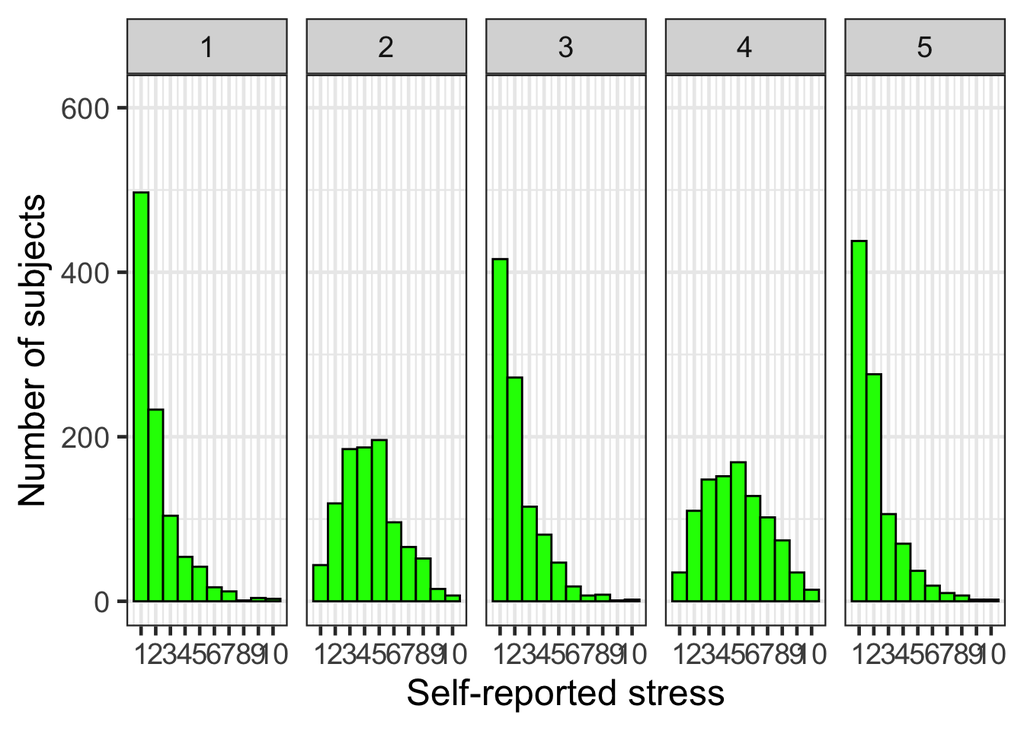

```r
ylimits = c(0, 610)
stressHist=ggplot()+
geom_histogram(data=f.Ldf, aes(stress_value), fill="green", binwidth=1, color="black") +
facet_wrap(~timepoint, ncol=5) +
labs(x="Self-reported stress", y="Number of subjects") +
ylim(ylimits)+
scale_x_continuous(breaks=c(1,2,3,4,5,6,7,8,9,10) )+
theme_bw(base_size=18)
stressHist
```

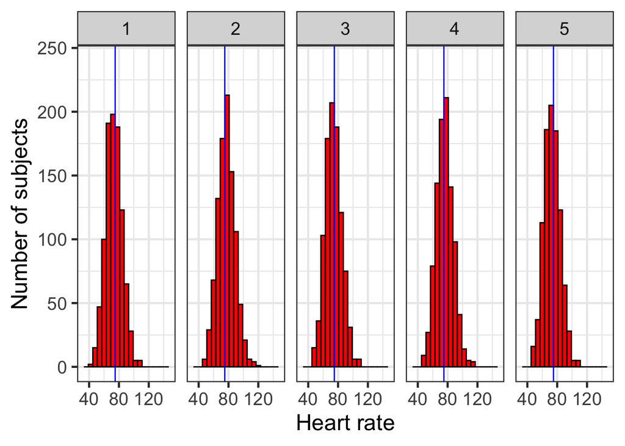

```r
xlimits = c(30,150)
ylimits = c(0, 240)
hrHist=ggplot()+
geom_histogram(data=f.Ldf, aes(hr_value), fill="red", binwidth=6, color="black") +
facet_wrap(~timepoint, ncol=5) +
labs(x="Heart rate", y="Number of subjects") +
ylim(ylimits)+
xlim(xlimits)+
geom_vline(xintercept=75, size=.5, color="blue")+
theme_bw(base_size=18)
hrHist
```